# Analyses de tendances

Mathilde Vimont

30 novembre, 2021

# Contexte

On veut savoir quelle est la tendance d’évolution de l’abondance de l’espèce *Galium aparine* sur les dernières années **(2009-2019)** i.e, si cette espèce voit son abondance augmenter, diminuer ou rester stable.

La métrique que vous avez choisie pour représenter cette abondance est : **frequence**

Pour étudier cette tendance, il est nécessaire de prendre en compte tout un ensemble de paramètres qui pourraient aussi jouer sur l’abondance (ex : localisation) ou indirectement sur la perception d’abondance de cette espèce (ex : type de protocole, conditions météorologiques, type d’outil, …).

Les variables que vous avez choisies pour faire ce contrôle sont : **longitude, latitude, site**

# 1. Tendance globale

Le modèle que vous avez choisi de réaliser est le suivant, avec une distribution de *binomial* :

```
## frequence ~ 1 + longitude + latitude + year + (1 | site)
## <environment: 0x000001d449c452f8>
```

Les résultats de cette régression sont regroupés dans le tableau suivant. On observe que le coefficient associé à la variable *year* n’est pas jugé comme significativement différent de 0.

|  | Estimates | Standard Errors | IC_inf | IC_sup | P Values | Significant |
| --- | --- | --- | --- | --- | --- | --- |
| (Intercept) | 6.92e-12 | 3.71e+15 | 6.40e-73 | 8.65e+24 | 7.20e-01 | No |
| longitude | 5.01e-01 | 5.22e-01 | 4.59e-01 | 5.45e-01 | 9.74e-01 | No |
| latitude | 5.35e-01 | 5.25e-01 | 4.87e-01 | 5.87e-01 | 1.60e-01 | No |
| year | 5.04e-01 | 5.14e-01 | 4.78e-01 | 5.31e-01 | 7.76e-01 | No |

# 2. Variations inter-annuelles

Ce graphique permet de voir l’évolution de l’abondance par rapport à l’année de référence, 2009.

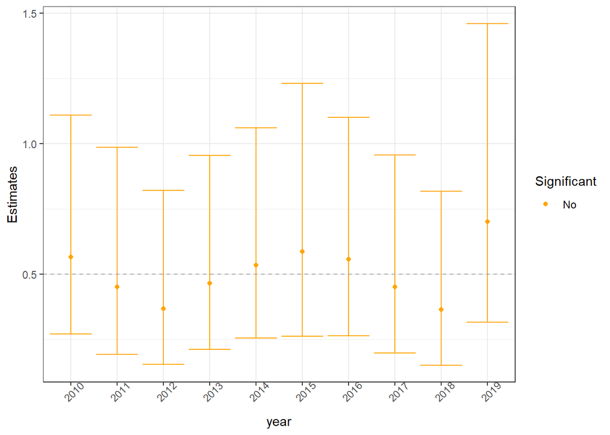

# 3. Et la qualité des modèles ?